# MAVEn_workflow

Megan L. Larsen & Juniper L. Simonis

```r
library(MAVEn)
```

# Overview

MAVEn data are exported from the instrument as a large table of instrument, CO<sub>2</sub>, and activity data for animals across 16 chambers. Here, we demonstrate a workflow pipeline for evaluating MAVEn metabolism and activity data with flexibility in calculating animal activity status.

There are two workflow strategies: (1) one that leverages all the functionality within the code base to work through and evaluate data in a step wise fashion and (2) one that integrates all the package functions into a single function, `evaluate_maven`, for fast data proc. Both are outlined below.

Functions are built on specific data, so it is imperative to make sure the information provided in each of the functions matches the function parameter.

## Data structure

Data are produced as a high-resolution time-series (1 second intervals) with instrument readings for connected probes (e.g. temperature, CO<sub>2</sub>, thermocouplers) and readings within the 16 chambers for CO<sub>2</sub> consumption and activity. Instrument readings begin in whichever chamber was the last to be recorded in the previous instrument run. The instrument defaults to a 120 second measurement per chamber, but it appears there is some variation in that measurement. In addition, there are 180 second measurements for baseline data (Chamber 0) collected in between readings for Chamber 16 and Chamber 1.

# Workflow pipeline

## Overview steps

1. Data are loaded into the space using `read_maven`, which removes all baseline data from the data set prior to processing.
2. Cycle numbers are assigned to the data using `assign_cyclenumber` with defaults for n_chambers = 16 and chamber measurement duration (chamber_measure_duration) = 120. This function will return the MAVEn data set with appended cycle numbers and is responsive to the chamber where the instrument started and stopped/
3. The complete data set is then deconstructed into a data set for the fly metabolism using `extract_metabolism` and fly activity using `extract_activity`.
4. These data are summarized individually using the functions `summarize_metabolism` and `summarize_activity`, which can produce either a summary table for each cycle within each chamber or for each chamber. They make use of the utility calculation functions `sem`, `lower.ci`, and `upper.ci`. `summarize_activity` provides both a calculated activity level for a specified time interval (e.g. +/- 30 sec) and an activity state based on a given threshold.
5. The final output data table is produced with `maven_datatable`, which provides the fly, cycle, median CO<sub>2</sub>, and activity for a MAVEn run.

## Instrument run overview

Evaluating the experimental time course is a vital step to check for issues with chamber sealing or measurements that may impact the experiment.

Here, we read in the full MAVEn data set that includes the baseline data by toggling `baseline = T` in the `read_maven` function.

```r
experiment_name <- "maven_analysis_output"
activity_interval_value <- 60
activity_baseline_value <- 0.01
activity_threshold_value <- 1
```

```r
maven_raw <- read_maven(datadir = "../inst/extdata",
                        maven_datafile = "./maven_output.csv", baseline = T)
tibble(maven_raw)
```

```
#> # A tibble: 4,218 x 66
#>    Seconds Date_Time CO2ppm WVppt RefBP   TC1   TC2 Volts_6 FRB_mlmin FRC_mlmin
#>      <int>     <dbl>  <dbl> <dbl> <dbl> <dbl> <dbl>   <dbl>     <dbl>     <dbl>
#>  1       0    62582.   1.26 10.0   103.  23.6  27.9    2.50      20.0      19.9
#>  2       1    62582.   1.25  9.01  103.  23.7  27.9    2.51      20.0      19.8
#>  3       2    62582.   1.25  8.95  103.  23.7  27.9    2.51      20.0      19.8
#>  4       3    62582.   1.24  8.87  103.  23.7  28.0    2.50      20.0      19.8
#>  5       4    62582.   1.24  8.82  103.  23.7  27.9    2.50      20.0      19.8
#>  6       5    62582.   1.24  8.77  103.  23.7  27.9    2.50      19.9      19.8
#>  7       6    62582.   1.24  8.70  103.  23.7  27.9    2.50      19.9      19.8
#>  8       7    62582.   1.24  8.66  103.  23.7  27.9    2.50      19.9      19.8
#>  9       8    62582.   1.23  8.59  103.  23.7  28.0    2.50      20.0      19.8
#> 10       9    62582.   1.23  8.54  103.  23.7  28.0    2.50      20.0      19.8
#> # ... with 4,208 more rows, and 56 more variables: Chamber <int>, TempC <dbl>,
#> #   RH_pct <dbl>, Light_Lux <dbl>, BP_kPa <dbl>, Act_1 <dbl>, Act_2 <dbl>,
#> #   Act_3 <dbl>, Act_4 <dbl>, Act_5 <dbl>, Act_6 <dbl>, Act_7 <dbl>,
#> #   Act_8 <int>, Act_9 <dbl>, Act_10 <dbl>, Act_11 <dbl>, Act_12 <dbl>,
#> #   Act_13 <dbl>, Act_14 <dbl>, Act_15 <int>, Act_16 <int>, c_FRC_mlmin <dbl>,
#> #   c_CO2ppm <dbl>, CO2_mlmin <dbl>, FlyChamber1 <int>, FlyChamber2 <int>,
#> #   FlyChamber3 <int>, FlyChamber4 <int>, FlyChamber5 <int>, FlyChamber6 <int>,
#> #   FlyChamber7 <int>, FlyChamber8 <int>, FlyChamber9 <int>,
#> #   FlyChamber10 <int>, FlyChamber11 <int>, FlyChamber12 <int>,
#> #   FlyChamber13 <int>, FlyChamber14 <int>, FlyChamber15 <int>,
#> #   FlyChamber16 <int>, CO2_mlminFly1 <dbl>, CO2_mlminFly2 <dbl>,
#> #   CO2_mlminFly3 <dbl>, CO2_mlminFly4 <dbl>, CO2_mlminFly5 <dbl>,
#> #   CO2_mlminFly6 <dbl>, CO2_mlminFly7 <dbl>, CO2_mlminFly8 <dbl>,
#> #   CO2_mlminFly9 <dbl>, CO2_mlminFly10 <dbl>, CO2_mlminFly11 <dbl>,
#> #   CO2_mlminFly12 <dbl>, CO2_mlminFly13 <dbl>, CO2_mlminFly14 <dbl>,
#> #   CO2_mlminFly15 <dbl>, CO2_mlminFly16 <dbl>
```

Raw data are imported into `plot_maven_overview` to produce four time series plots of the Chamber, instrument carbon dioxide (CO<sub>2</sub>) concentration (parts per million, ppm), flow rate (mL min<sup>-1) in the sample/animal chamber (FRC_mlmin), and thermocouple 1.</sup>

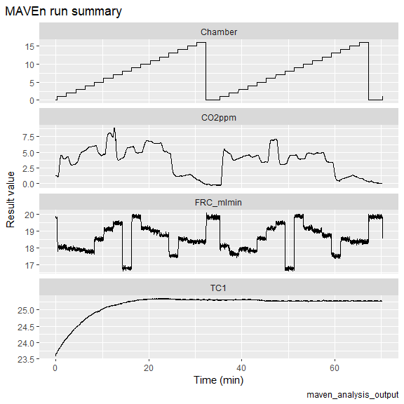

```r
plot_maven_overview(maven_raw, maven_experiment = experiment_name)
```

## Processing MAVEn data

### **Step 1**: Load the MAVEn data set without baseline

Baseline data from all downstream calculations, with the exception of the metabolism and activity visual diagnostics. However, if baseline data are required, simply change the baseline toggle to `TRUE`.

```r
maven <- read_maven(datadir = "../inst/extdata",
                    maven_datafile = "./maven_output.csv", baseline = F)
tibble(maven)
```

```
#> # A tibble: 3,842 x 66
#>    Seconds Date_Time CO2ppm WVppt RefBP   TC1   TC2 Volts_6 FRB_mlmin FRC_mlmin
#>      <int>     <dbl>  <dbl> <dbl> <dbl> <dbl> <dbl>   <dbl>     <dbl>     <dbl>
#>  1      17    62582.   1.21  8.12  103.  23.7  28.0    2.50      20.1      19.8
#>  2      18    62582.   1.20  8.07  103.  23.7  28.0    2.50      20.8      19.5
#>  3      19    62582.   1.19  8.02  103.  23.7  28.0    2.50      20.4      18.8
#>  4      20    62582.   1.12  7.97  103.  23.7  27.9    2.50      19.9      18.0
#>  5      21    62582.   1.09  7.92  103.  23.7  28.0    2.50      19.7      17.8
#>  6      22    62582.   1.14  7.88  103.  23.7  28.0    2.50      19.9      17.9
#>  7      23    62582.   1.20  7.84  103.  23.7  28.0    2.50      20.0      18
#>  8      24    62582.   1.21  7.80  103.  23.7  28.0    2.50      20.1      18.1
#>  9      25    62582.   1.21  7.77  103.  23.7  27.9    2.51      19.9      17.9
#> 10      26    62582.   1.19  7.72  103.  23.8  28.0    2.50      20.0      18.0
#> # ... with 3,832 more rows, and 56 more variables: Chamber <int>, TempC <dbl>,
#> #   RH_pct <dbl>, Light_Lux <dbl>, BP_kPa <dbl>, Act_1 <dbl>, Act_2 <dbl>,
#> #   Act_3 <dbl>, Act_4 <dbl>, Act_5 <dbl>, Act_6 <dbl>, Act_7 <dbl>,
#> #   Act_8 <int>, Act_9 <dbl>, Act_10 <dbl>, Act_11 <dbl>, Act_12 <dbl>,
#> #   Act_13 <dbl>, Act_14 <dbl>, Act_15 <int>, Act_16 <int>, c_FRC_mlmin <dbl>,
#> #   c_CO2ppm <dbl>, CO2_mlmin <dbl>, FlyChamber1 <int>, FlyChamber2 <int>,
#> #   FlyChamber3 <int>, FlyChamber4 <int>, FlyChamber5 <int>, FlyChamber6 <int>,
#> #   FlyChamber7 <int>, FlyChamber8 <int>, FlyChamber9 <int>,
#> #   FlyChamber10 <int>, FlyChamber11 <int>, FlyChamber12 <int>,
#> #   FlyChamber13 <int>, FlyChamber14 <int>, FlyChamber15 <int>,
#> #   FlyChamber16 <int>, CO2_mlminFly1 <dbl>, CO2_mlminFly2 <dbl>,
#> #   CO2_mlminFly3 <dbl>, CO2_mlminFly4 <dbl>, CO2_mlminFly5 <dbl>,
#> #   CO2_mlminFly6 <dbl>, CO2_mlminFly7 <dbl>, CO2_mlminFly8 <dbl>,
#> #   CO2_mlminFly9 <dbl>, CO2_mlminFly10 <dbl>, CO2_mlminFly11 <dbl>,
#> #   CO2_mlminFly12 <dbl>, CO2_mlminFly13 <dbl>, CO2_mlminFly14 <dbl>,
#> #   CO2_mlminFly15 <dbl>, CO2_mlminFly16 <dbl>
```

### **Step 2**: Assign a cycle number to the data

Cycle numbers refer to the complete measurement of Chambers 1 - 16. When the instrument run is started, measurements begin in the chamber where the instrument run last finished rather than restarting with a baseline (Chamber 0) or Chamber 1. Measurements continue until the instrument run is terminated, which could occur in the middle of a chamber’s measurement. Cycle assignment using `assign_cyclenumber` is responsive to those cases and will only assign a cycle number to data that are part of a complete cycle.

```r
maven_cycle <- assign_cyclenumber(maven)

tibble(maven_cycle)
```

```
#> # A tibble: 3,842 x 67
#>    Seconds Date_Time CO2ppm WVppt RefBP   TC1   TC2 Volts_6 FRB_mlmin FRC_mlmin
#>      <int>     <dbl>  <dbl> <dbl> <dbl> <dbl> <dbl>   <dbl>     <dbl>     <dbl>
#>  1      17    62582.   1.21  8.12  103.  23.7  28.0    2.50      20.1      19.8
#>  2      18    62582.   1.20  8.07  103.  23.7  28.0    2.50      20.8      19.5
#>  3      19    62582.   1.19  8.02  103.  23.7  28.0    2.50      20.4      18.8
#>  4      20    62582.   1.12  7.97  103.  23.7  27.9    2.50      19.9      18.0
#>  5      21    62582.   1.09  7.92  103.  23.7  28.0    2.50      19.7      17.8
#>  6      22    62582.   1.14  7.88  103.  23.7  28.0    2.50      19.9      17.9
#>  7      23    62582.   1.20  7.84  103.  23.7  28.0    2.50      20.0      18
#>  8      24    62582.   1.21  7.80  103.  23.7  28.0    2.50      20.1      18.1
#>  9      25    62582.   1.21  7.77  103.  23.7  27.9    2.51      19.9      17.9
#> 10      26    62582.   1.19  7.72  103.  23.8  28.0    2.50      20.0      18.0
#> # ... with 3,832 more rows, and 57 more variables: Chamber <int>, TempC <dbl>,
#> #   RH_pct <dbl>, Light_Lux <dbl>, BP_kPa <dbl>, Act_1 <dbl>, Act_2 <dbl>,
#> #   Act_3 <dbl>, Act_4 <dbl>, Act_5 <dbl>, Act_6 <dbl>, Act_7 <dbl>,
#> #   Act_8 <int>, Act_9 <dbl>, Act_10 <dbl>, Act_11 <dbl>, Act_12 <dbl>,
#> #   Act_13 <dbl>, Act_14 <dbl>, Act_15 <int>, Act_16 <int>, c_FRC_mlmin <dbl>,
#> #   c_CO2ppm <dbl>, CO2_mlmin <dbl>, FlyChamber1 <int>, FlyChamber2 <int>,
#> #   FlyChamber3 <int>, FlyChamber4 <int>, FlyChamber5 <int>, FlyChamber6 <int>,
#> #   FlyChamber7 <int>, FlyChamber8 <int>, FlyChamber9 <int>,
#> #   FlyChamber10 <int>, FlyChamber11 <int>, FlyChamber12 <int>,
#> #   FlyChamber13 <int>, FlyChamber14 <int>, FlyChamber15 <int>,
#> #   FlyChamber16 <int>, CO2_mlminFly1 <dbl>, CO2_mlminFly2 <dbl>,
#> #   CO2_mlminFly3 <dbl>, CO2_mlminFly4 <dbl>, CO2_mlminFly5 <dbl>,
#> #   CO2_mlminFly6 <dbl>, CO2_mlminFly7 <dbl>, CO2_mlminFly8 <dbl>,
#> #   CO2_mlminFly9 <dbl>, CO2_mlminFly10 <dbl>, CO2_mlminFly11 <dbl>,
#> #   CO2_mlminFly12 <dbl>, CO2_mlminFly13 <dbl>, CO2_mlminFly14 <dbl>,
#> #   CO2_mlminFly15 <dbl>, CO2_mlminFly16 <dbl>, cycle <chr>
```

### **Step 3a**: Extract the metabolism data from the data set

Extracting information from the larger data set provides a mechanism to only use the critical pieces of information. Animal metabolism is associated with CO<sub>2</sub> production within a given chamber. These data are extracted from the CO2_mlminFly1:CO2_mlminFly16 columns in cycle-assign MAVEn data set using `extract_metabolism`.

```r
animal_metabolism <- extract_metabolism(maven_cycle)

tibble(animal_metabolism)
```

```
#> # A tibble: 3,830 x 22
#>    Seconds Date_Time CO2ppm WVppt RefBP   TC1   TC2 Volts_6 FRB_mlmin FRC_mlmin
#>      <int>     <dbl>  <dbl> <dbl> <dbl> <dbl> <dbl>   <dbl>     <dbl>     <dbl>
#>  1      17    62582.   1.21  8.12  103.  23.7  28.0    2.50      20.1      19.8
#>  2      18    62582.   1.20  8.07  103.  23.7  28.0    2.50      20.8      19.5
#>  3      19    62582.   1.19  8.02  103.  23.7  28.0    2.50      20.4      18.8
#>  4      20    62582.   1.12  7.97  103.  23.7  27.9    2.50      19.9      18.0
#>  5      21    62582.   1.09  7.92  103.  23.7  28.0    2.50      19.7      17.8
#>  6      22    62582.   1.14  7.88  103.  23.7  28.0    2.50      19.9      17.9
#>  7      23    62582.   1.20  7.84  103.  23.7  28.0    2.50      20.0      18
#>  8      24    62582.   1.21  7.80  103.  23.7  28.0    2.50      20.1      18.1
#>  9      25    62582.   1.21  7.77  103.  23.7  27.9    2.51      19.9      17.9
#> 10      26    62582.   1.19  7.72  103.  23.8  28.0    2.50      20.0      18.0
#> # ... with 3,820 more rows, and 12 more variables: Chamber <int>, TempC <dbl>,
#> #   RH_pct <dbl>, Light_Lux <dbl>, BP_kPa <dbl>, c_FRC_mlmin <dbl>,
#> #   c_CO2ppm <dbl>, CO2_mlmin <dbl>, cycle <chr>, parameter <dbl>,
#> #   result <dbl>, measurement_number <dbl>
```

### **Step 3b**: Visualize the trend data to check for issues in measurements

`extract_metabolism` also standardizes the time course readings to a measurement number (Second - min(Second)) to produce a consistent visualization of the data by cycle. There are additional parameters added for saving the graphical output if needed. By default, the image is saved as a `.png` named `MetabolismTrends.png`. These plots are generated with the ggplot2 package, which means they can be modified with themes, colors, etc. by assigning them to a value.

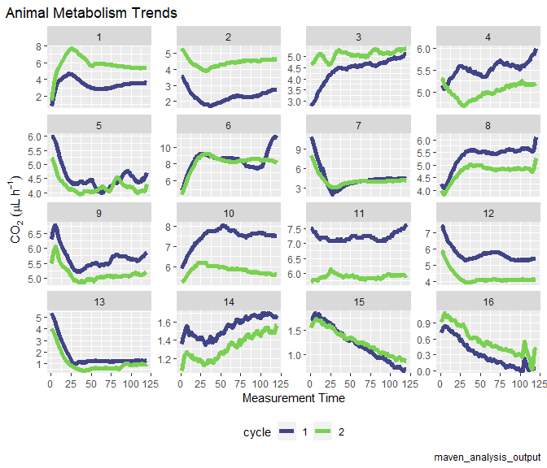

```r
metabolism_trend(animal_metabolism, maven_experiment = experiment_name)
```

```r
p <- metabolism_trend(animal_metabolism, maven_experiment = experiment_name)
p + scale_color_brewer(palette = "Dark2")
```

[output not shown]

[figure not shown]

### **Step 4**: Summarize animal metabolism

Individual chamber readings by cycle and summarized readings for the entire instrument run can be created using `summarize_metabolism`. To create a table for all data (“by_cycle”) or summarized by chamber (“by_chamber”).

```r
metabolism_summary_cycle <- summarize_metabolism(animal_metabolism,
                                                 type = "by_cycle")
```

| Chamber | cycle | median_co2_ul.h | median_time | median_temp |
| --- | --- | --- | --- | --- |
| 1 | 1 | 3.444 | 76.5 | 23.62 |
| 1 | 2 | 5.724 | 2176 | 25.56 |
| 2 | 1 | 2.286 | 196.5 | 23.87 |
| 2 | 2 | 4.479 | 2296 | 25.56 |
| 3 | 1 | 4.581 | 316.5 | 24.24 |
| 3 | 2 | 5.136 | 2416 | 25.56 |

```r
metabolism_summary_chamber <- summarize_metabolism(animal_metabolism,
                                                   type = "by_chamber")
```

| Chamber | mean | sd | n | sem | lower.ci | upper.ci |
| --- | --- | --- | --- | --- | --- | --- |
| 1 | 4.584 | 1.612 | 2 | 1.14 | -9.901 | 19.07 |
| 2 | 3.382 | 1.551 | 2 | 1.096 | -10.55 | 17.31 |
| 3 | 4.859 | 0.3924 | 2 | 0.2775 | 1.333 | 8.384 |
| 4 | 5.289 | 0.3649 | 2 | 0.258 | 2.011 | 8.567 |
| 5 | 4.271 | 0.1846 | 2 | 0.1305 | 2.612 | 5.929 |
| 6 | 8.55 | 0.1273 | 2 | 0.09 | 7.406 | 9.694 |

### **Step 5**: Visual diagnostic of calculated data on raw data

Using the MAVEn output with baseline (generated by `baseline = T`) as the base, `metabolism_diag` plots the median measurement time and median metabolism value onto the raw data for quick visual confirmation that the data calculated match the raw data.

This figure also saves the graphic by default as `MetabolismDiagnostics.png`

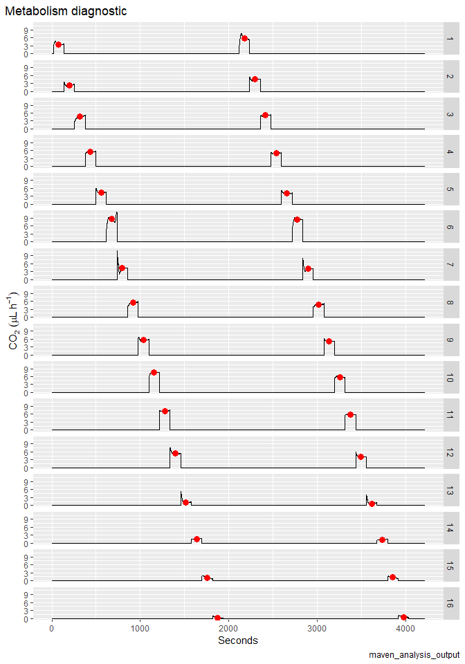

```r
metabolism_diag(maven_raw, metabolism_summary_cycle,
                maven_experiment = experiment_name)
```

### **Step 6a**: Extract animal activity data based on metabolism calculations

CO2 measurements are recorded for 120 seconds while animal activity is continuously recorded during an experimental run. Thus, it would be possible to measure an animal’s activity for longer than the CO2 measurement window in a specific chamber. However, because of how the instrument begins and ends an experimental run, having a consist number of activity readings outside the metabolism measurement may not be achievable. `extract_activity` requires the user to input an interval (measured in seconds) and a threshold activity level. Given the variability in where the instrument starts measurements, it is recommended to select a value no longer than 60 seconds (within the CO2 measurement interval)

```r
animal_activity <- extract_activity(maven_cycle, metabolism_summary_cycle,
                                interval = activity_interval_value,
                                activity_baseline = activity_baseline_value)
tibble(animal_activity)
```

```
#> # A tibble: 3,834 x 28
#>    Seconds Date_Time CO2ppm WVppt RefBP   TC1   TC2 Volts_6 FRB_mlmin FRC_mlmin
#>      <int>     <dbl>  <dbl> <dbl> <dbl> <dbl> <dbl>   <dbl>     <dbl>     <dbl>
#>  1      17    62582.   1.21  8.12  103.  23.7  28.0    2.50      20.1      19.8
#>  2      18    62582.   1.20  8.07  103.  23.7  28.0    2.50      20.8      19.5
#>  3      19    62582.   1.19  8.02  103.  23.7  28.0    2.50      20.4      18.8
#>  4      20    62582.   1.12  7.97  103.  23.7  27.9    2.50      19.9      18.0
#>  5      21    62582.   1.09  7.92  103.  23.7  28.0    2.50      19.7      17.8
#>  6      22    62582.   1.14  7.88  103.  23.7  28.0    2.50      19.9      17.9
#>  7      23    62582.   1.20  7.84  103.  23.7  28.0    2.50      20.0      18
#>  8      24    62582.   1.21  7.80  103.  23.7  28.0    2.50      20.1      18.1
#>  9      25    62582.   1.21  7.77  103.  23.7  27.9    2.51      19.9      17.9
#> 10      26    62582.   1.19  7.72  103.  23.8  28.0    2.50      20.0      18.0
#> # ... with 3,824 more rows, and 18 more variables: Chamber <int>, TempC <dbl>,
#> #   RH_pct <dbl>, Light_Lux <dbl>, BP_kPa <dbl>, cycle <chr>,
#> #   c_FRC_mlmin <dbl>, c_CO2ppm <dbl>, CO2_mlmin <dbl>, parameter <dbl>,
#> #   result <dbl>, median_co2_ul.h <dbl>, median_time <dbl>, median_temp <dbl>,
#> #   act_start <dbl>, act_end <dbl>, measurement_number <dbl>, result_flag <chr>
```

### **Step 6b**: Plot animal activity

As with the metabolism data, activity trends can also be plotted with the standardized measurement number.

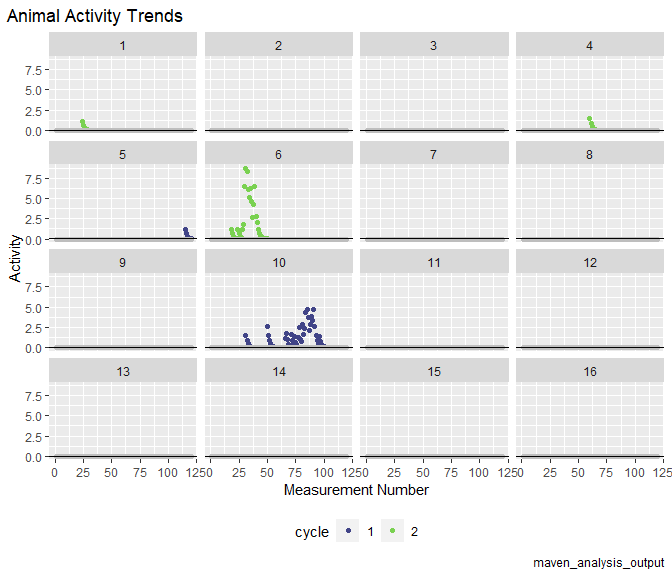

```r
activity_trend(animal_activity, maven_experiment = experiment_name,
               activity_baseline = activity_baseline_value)
```

### **Step 7**: Generate animal activity summary tables

```r
activity_summary_cycle <- summarize_activity(animal_activity,
                                             type = "by_cycle",
                                             activity_threshold =
                                               activity_threshold_value)
```

| Chamber | cycle | mean_activity | median_activity | activity_state |
| --- | --- | --- | --- | --- |
| 1 | 1 | NA | NA | Inactive (< Threshold) |
| 2 | 1 | NA | NA | Inactive (< Threshold) |
| 3 | 1 | NA | NA | Inactive (< Threshold) |
| 4 | 1 | NA | NA | Inactive (< Threshold) |
| 5 | 1 | 0.4133 | 0.28 | Inactive |
| 6 | 1 | NA | NA | Inactive (< Threshold) |

```r
activity_summary_chamber <- summarize_activity(animal_activity,
                                               type = "by_chamber")
```

| Chamber | mean | sd | n | sem | lower.ci | upper.ci |
| --- | --- | --- | --- | --- | --- | --- |
| 1 | 0.256 | NA | 2 | NA | NA | NA |
| 2 | NA | NA | 2 | NA | NA | NA |
| 3 | NA | NA | 2 | NA | NA | NA |
| 4 | 0.342 | NA | 2 | NA | NA | NA |
| 5 | 0.4133 | NA | 2 | NA | NA | NA |
| 6 | 2.262 | NA | 2 | NA | NA | NA |

### **Step 8:** Visual diagnostic of animal activity

Visual diagnostics for the animal activity data are presented with the median metabolism rates for each cycle within a chamber.

The periods of activity measurements are indicated by a colored rectangle that specifies the calculated activity status of the animal at the time of measurement with respect to the selected activity threshold, set by the parameter `activity_threshold` in `activity_summary_cycle`.

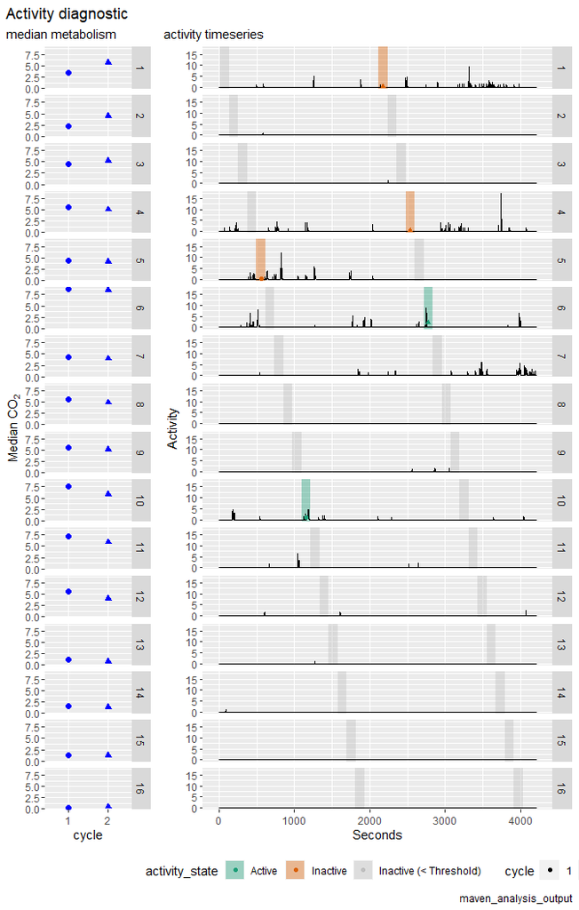

```r
activity_diag(maven_raw, metabolism_summary_cycle, activity_summary_cycle,
              maven_experiment = experiment_name,
              interval = activity_interval_value)
```

### **Step 9**: Create the finalized data table

```r
maven_datatable(metabolism_summary_cycle, activity_summary_cycle,
                            maven_experiment = experiment_name)
```

```
#> # A tibble: 32 x 8
#> # Groups:   Chamber [16]
#>    Chamber cycle median_co2_ul.h median_time median_temp mean_activity
#>      <int> <chr>           <dbl>       <dbl>       <dbl>         <dbl>
#>  1       1 1                3.44        76.5        23.6        NA
#>  2       1 2                5.72      2176.         25.6         0.256
#>  3       2 1                2.29       196.         23.9        NA
#>  4       2 2                4.48      2296.         25.6        NA
#>  5       3 1                4.58       316.         24.2        NA
#>  6       3 2                5.14      2416.         25.6        NA
#>  7       4 1                5.55       436.         24.5        NA
#>  8       4 2                5.03      2536.         25.5         0.342
#>  9       5 1                4.40       556.         24.8         0.413
#> 10       5 2                4.14      2656.         25.5        NA
#> # ... with 22 more rows, and 2 more variables: median_activity <dbl>,
#> #   activity_state <chr>
```

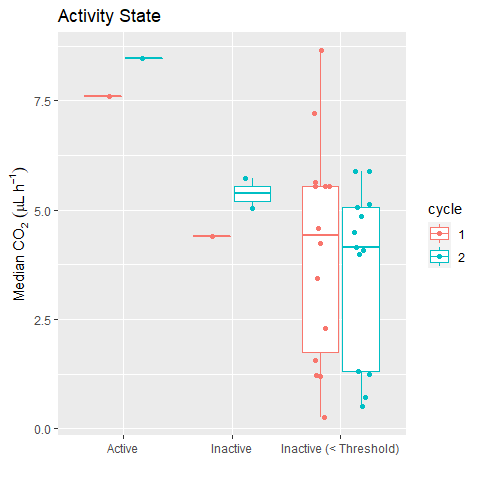

```r
test.out <- maven_datatable(metabolism_summary_cycle, activity_summary_cycle,
                            maven_experiment = experiment_name)


ggplot(test.out, aes(x = activity_state, y = median_co2_ul.h, col = cycle)) +
  geom_boxplot() +
  geom_point(position = position_jitterdodge(jitter.width = 0.2,
                                             dodge.width = 0.7)) +
  labs(title = "Activity State", x = "",
       y = expression(Median~CO[2]~(mu*L~h^-1)))
```

## OPT2: Complete analysis workflow

Using this single function, you can quickly and easily evaluate a MAVEn experiment without needing to interface with underlying functions.

```r
evaluate_maven(datadir = "../data",
               maven_datafile = "maven_output.csv",
               maven_experiment = "test.evaluate",
               activity_baseline = 0.01, activity_threshold = 1)
```